# R for Data Science

## 2.4 Exercises

1. How does the distribution of flight times within a day change over the course of the year?

1일 이내의 비행 시간 분포는 연중 어떻게 변하는가?

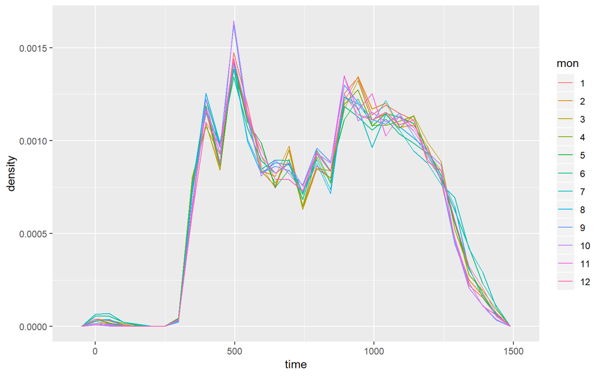

```r
flights_dt %>%
  mutate(time = hour(dep_time) * 60 + minute(dep_time),
         mon = as.factor(month(dep_time))) %>%
  ggplot(aes(time, group = mon, color = mon)) +
    geom_freqpoly(aes(y = ..density..))
```

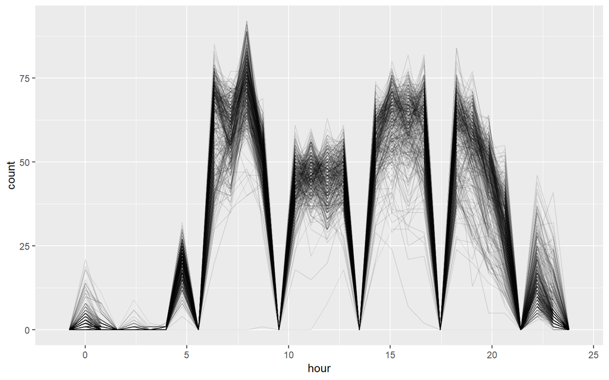

```r
flights_dt %>%
  mutate(date = make_date(year(dep_time),
                          month(dep_time),
                          mday(dep_time)),
         hour = hour(dep_time)) %>%
  group_by(date, hour) %>%
  ggplot(mapping = aes(x = hour, group = date)) +
  geom_freqpoly(alpha = .1)
```

이 문제 해석하기 나름인거 같은데..

2. Compare dep_time, sched_dep_time, and dep_delay. Are they consistent? Explain your findings.

```r
flights_dt %>%
  mutate(dep_time_ = sched_dep_time + dep_delay* 60) %>%
  filter(dep_time_ != dep_time) %>%
  select(dep_time, dep_time_, sched_dep_time, dep_delay)
```

```
## # A tibble: 1,205 x 4
##    dep_time            dep_time_           sched_dep_time      dep_delay
##    <dttm>              <dttm>              <dttm>                  <dbl>
##  1 2013-01-01 08:48:00 2013-01-02 08:48:00 2013-01-01 18:35:00       853
##  2 2013-01-02 00:42:00 2013-01-03 00:42:00 2013-01-02 23:59:00        43
##  3 2013-01-02 01:26:00 2013-01-03 01:26:00 2013-01-02 22:50:00       156
##  4 2013-01-03 00:32:00 2013-01-04 00:32:00 2013-01-03 23:59:00        33
##  5 2013-01-03 00:50:00 2013-01-04 00:50:00 2013-01-03 21:45:00       185
##  6 2013-01-03 02:35:00 2013-01-04 02:35:00 2013-01-03 23:59:00       156
##  7 2013-01-04 00:25:00 2013-01-05 00:25:00 2013-01-04 23:59:00        26
##  8 2013-01-04 01:06:00 2013-01-05 01:06:00 2013-01-04 22:45:00       141
##  9 2013-01-05 00:14:00 2013-01-06 00:14:00 2013-01-05 23:59:00        15
## 10 2013-01-05 00:37:00 2013-01-06 00:37:00 2013-01-05 22:30:00       127
## # ... with 1,195 more rows
```

예전에 연습문제에 풀었듯이 예정된 시간을 넘어서서 하루가 지나면 이런 차이가 생긴다.

```r
# 이걸 고치기 위해서
flights_dt %>%
  mutate(dep_time_ = sched_dep_time + dep_delay * 60) %>%
   mutate(dep_time_ = ifelse(dep_time_ != dep_time, dep_time_ - 86400, dep_time_)) %>%
  filter(dep_time_ != dep_time) %>%
  select(dep_time, dep_time_, sched_dep_time, dep_delay)
```

```
## # A tibble: 0 x 4
## # ... with 4 variables: dep_time <dttm>, dep_time_ <dbl>,
## #   sched_dep_time <dttm>, dep_delay <dbl>
```

```r
# 두번째 : update
flights_dt %>% select(contains("dep")) %>%
  mutate(cal_delay = as.numeric(dep_time - sched_dep_time) / 60) %>%
  filter(dep_delay != cal_delay) %>%
  mutate(dep_time = update(dep_time, mday = mday(dep_time) + 1)) %>%
  mutate(cal_delay = as.numeric(dep_time - sched_dep_time)) %>%
  filter(dep_delay != cal_delay)
```

```
## # A tibble: 0 x 4
## # ... with 4 variables: dep_delay <dbl>, dep_time <dttm>,
## #   sched_dep_time <dttm>, cal_delay <dbl>
```

3. Compare air_time with the duration between the departure and arrival. Explain your findings. (Hint: consider the location of the airport.)

```r
flights_dt %>%
  mutate(cal_air_time = as.numeric(arr_time - dep_time)) %>%
  select(contains("air_time"))
```

```
## # A tibble: 328,063 x 2
##    air_time cal_air_time
##       <dbl>        <dbl>
##  1      227          193
##  2      227          197
##  3      160          221
##  4      183          260
##  5      116          138
##  6      150          106
##  7      158          198
##  8       53           72
##  9      140          161
## 10      138          115
## # ... with 328,053 more rows
```

뉴욕과 시카고의 시차는 1시간인데 그것까지 고려해도 오차가 있다.

```r
flights_dt %>%
  left_join(airports, by = c("origin" = "faa")) %>%
  left_join(airports, by = c("dest" = "faa"), suffix = c(".origin",".dest")) %>%
  select(dep_time, arr_time, air_time, contains("tzone")) %>%
  print(width = Inf)
```

```
## # A tibble: 328,063 x 5
##    dep_time            arr_time            air_time tzone.origin
##    <dttm>              <dttm>                 <dbl> <chr>
##  1 2013-01-01 05:17:00 2013-01-01 08:30:00      227 America/New_York
##  2 2013-01-01 05:33:00 2013-01-01 08:50:00      227 America/New_York
##  3 2013-01-01 05:42:00 2013-01-01 09:23:00      160 America/New_York
##  4 2013-01-01 05:44:00 2013-01-01 10:04:00      183 America/New_York
##  5 2013-01-01 05:54:00 2013-01-01 08:12:00      116 America/New_York
##  6 2013-01-01 05:54:00 2013-01-01 07:40:00      150 America/New_York
##  7 2013-01-01 05:55:00 2013-01-01 09:13:00      158 America/New_York
##  8 2013-01-01 05:57:00 2013-01-01 07:09:00       53 America/New_York
##  9 2013-01-01 05:57:00 2013-01-01 08:38:00      140 America/New_York
## 10 2013-01-01 05:58:00 2013-01-01 07:53:00      138 America/New_York
##    tzone.dest
##    <chr>
##  1 America/Chicago
##  2 America/Chicago
##  3 America/New_York
##  4 <NA>
##  5 America/New_York
##  6 America/Chicago
##  7 America/New_York
##  8 America/New_York
##  9 America/New_York
## 10 America/Chicago
## # ... with 328,053 more rows
```

다음으로 arr_time과 dep_time의 차이를 시간대 정보를 가지고 계산하자. `force_tz()`을 사용하여 시간정보를 덧붙일 수 있다. `force_tz()`는 관련된 시간정보를 변화하는 동안 같은 시간을 유지한다.

**force_tz**

`force_tz()` returns the date-time that has the same clock time as input time, but in the new time zone.

DST(Daylight saving time, 일광 절약 시간제)는 하절기에 표준시를 원래 시간보다 한 시간 앞당긴 시간을 쓰는 것을 말한다.

```r
x <- ymd_hms("2009-08-07 00:00:01", tz = "America/New_York")
force_tz(x, "UTC")
```

```
## [1] "2009-08-07 00:00:01 UTC"
```

```r
force_tz(x, "Europe/Amsterdam")
```

```
## [1] "2009-08-07 00:00:01 CEST"
```

```r
# DST skip
y <- ymd_hms("2010-03-14 02:05:05 UTC")
force_tz(y, "America/New_York", roll=FALSE)
```

```
## [1] NA
```

```r
force_tz(y, "America/New_York", roll=TRUE)
```

```
## [1] "2010-03-14 03:00:00 EDT"
```

```r
## Heterogeneous time-zones :
x <- ymd_hms(c("2009-08-07 00:00:01", "2009-08-07 01:02:03"))
force_tzs(x, tzones = c("America/New_York", "Europe/Amsterdam"))
```

```
## [1] "2009-08-07 04:00:01 UTC" "2009-08-06 23:02:03 UTC"
```

```r
flights_dt %>%
  left_join(airports, by = c("origin" = "faa")) %>%
  left_join(airports, by = c("dest" = "faa"), suffix = c(".origin", ".dest")) %>%
  select(dep_time, arr_time, air_time, contains("tzone")) %>%
  filter(!is.na(tzone.origin), !is.na(tzone.dest)) %>%
  mutate(dep_time = force_tzs(dep_time, tzones = tzone.origin),
         arr_time = force_tzs(arr_time, tzones = tzone.dest),
         cal_air_time = as.numeric(arr_time - dep_time) * 60) %>% select(contains("air"))
```

```
## # A tibble: 320,503 x 2
##    air_time cal_air_time
##       <dbl>        <dbl>
##  1      227        15180
##  2      227        15420
##  3      160        13260
##  4      116         8280
##  5      150         9960
##  6      158        11880
##  7       53         4320
##  8      140         9660
##  9      138        10500
## 10      149        10260
## # ... with 320,493 more rows
```

참고로 arr_time - dep_time을 하게 되면 지나치게 큰 음수값이 많은데 하루가 지나고 도착해서 그렇다. (arr_time - dep_time) %% 60 * 24을 통해서 이 부분은 해소가 된다.